# Proyecto_R

[figure not shown]

## Accidentes de Tránsito en los Estados Unidos

[figure not shown]

Las muertes por automóviles son una imperiosa preocupación de salud pública. Se trata de **la segunda causa de muerte accidental en el país**, después de las sobredosis por drogas. Sin embargo, las legislaturas estatales están rezagadas de cara a esta realidad y no toman las medidas necesarias para desacelerar el ritmo de muertes y accidentes, según informa un grupo defensor de la seguridad vial.

En el informe de 2018 relativo a las leyes de tránsito estatales, la organización *Advocates for Highway and Auto Safety* (Defendiendo la Seguridad Vial y Automotriz) concluye que solo seis estados muestran “avances significativos” en pos de adoptar 16 leyes que ellos consideran “esenciales para salvar vidas, evitar lesiones y reducir cuidados médicos y otros costos”.

Por ejemplo: **cerca de la mitad del total de automovilistas que murieron en accidentes durante los últimos 5 años no tenían puesto el cinturón de seguridad**, mientras que 16 estados todavía carecen de regulaciones para reforzar el uso obligatorio de éste. Asimismo, la tasa de muertes por conducir bajo los efectos del alcohol está aumentando; Pese a ello, **20 estados no han aprobado normativas que requieran alcoholímetros para previos infractores**, y 9 no disponen de leyes para fiscalizar la presencia de una lata o una botella abierta en el auto. Y aunque el 40% de los motociclistas fallecidos no llevaba casco, más estados rechazan los requerimientos de estos medios de protección que los que los imponen.

Pero algo mueve al optimismo: 13 leyes de “seguridad básica” fueron aprobadas estatalmente en 2017, según el reporte. En 2015 y 2016 solo habían ocho y cinco leyes de ese tipo, respectivamente.

Por otra parte, las leyes son tan buenas como se hacen cumplir. Un buen ejemplo: los choferes que tienen sus ojos, manos, y cerebros pendientes al sonido del teléfono o a los sistemas de info-entretenimiento y navegación de sus vehículos están complicando el panorama. Las así llamadas muertes por distracción al volante han crecido en muchos de los estados que aprobaron regulaciones para controlar el número de estas, ya fuera a través de dispositivos manuales o prohibiciones de mensajes de texto. Eso se ha debido en gran medida a que, según el informe, **el modo de hacer cumplir estas leyes ha sido laxo y fácil de evadir**. Más aún, pese a que la distracción con los llamados manos libres **podría ser tan peligrosa como con las manos ocupadas**, ningún estado ha vetado el uso de celulares en general.

Por si no bastara, las condiciones en carretera podrían ser incluso más peligrosas de lo que sugiere el reporte, ya que éste no evalúa las leyes de límite de velocidad. El número de estados subiendo sus límites ha aumentado recientemente, siendo Nevada el último en permitir que los choferes lleguen a 80 millas por hora en algunos tramos de las autopistas. La velocidad, ni qué decir tiene, es una de las causas de accidentes mortales más ampliamente reportadas, y **podría ser uno de los factores del que más al tanto estén los legisladores** según la **Junta Nacional de Seguridad del Transporte** (NTSB, por sus siglas en inglés). **Bajar los límites de velocidad pudiera salvar vidas**, evidencia su investigación; Francia, recientemente, rebajó esos límites en las autopistas de doble sentido, en respuesta al creciente número de muertes en carretera.

La NTSB instó a todos los estados a que revisaran, radicalmente, **cómo establecen sus límites de velocidad**: no solo hallando la velocidad promedio de los automovilistas, como invitó a hacer por mucho tiempo un desactualizado estudio federal, sino “también teniendo en cuenta las condiciones de la carretera, el estado de la infraestructura al costado de las vías, el estacionamiento, la presencia de peatones y el historial de accidentes en la zona”, precisó la revista *Governing*. Estas recomendaciones son muy pertinentes, habida cuenta que los estados rara vez consideran las condiciones locales al establecer sus límites de velocidad.

Menos y más estrechos carriles, y la protección de los cruces para peatones y ciclistas –cuyo índice de fatalidades en carreteras subieron, respectivamente, un 9% y un 1.3% en 2016– han demostrado que salvan vidas haciendo reducir la velocidad y amparando a los usuarios más vulnerables. Decenas de ciudades, un puñado de estados, e incluso el Departamento de Transporte de Estados Unidos han adoptado o modelado políticas tras Vision Zero, la campaña internacional encaminada a poner fin a los accidentes automovilísticos nocivos por medio de una mejor vigilancia de las leyes, de educación para la seguridad y una ingeniería civil intencionada. Los mejores resultados hasta ahora parecen estar relacionados con ese última “I” –aunque las muertes de peatones y ciclistas en la ciudad de Nueva York, en general, **han aumentado** desde que la urbe se comprometió seguir la pauta de Vision Zero, las muertes **en intersecciones especialmente rediseñadas han disminuido**.

Según la Organización Mundial de la Salud, **Estados Unidos se ubica en la posición 41 entre las 52 naciones de más altos ingresos en lo relacionado a muertes por accidentes de tránsito**, superado solo por Qatar, Arabia Saudita y Rusia.

**Fuente:** *Univisión Noticias*

**Autor:** *Laura Bliss*

**Fecha:** *13 de Marzo del 2018*

> **Nota:** A pesar que está información no es actual brinda una importante base para el enfoque de este análisis, ya que se tiene un punto de partida como referencia, la cuál permitirá hacer una comparativa con los resultados obtenidos y así poder brindar conclusiones respecto al manejo de los accidentes de tránsito en los Estados Unidos.

### Objetivos

**General**

Indentificar las causas principales de accidentes de tránsito en los Estados Unidos, así como su impacto en la sociedad estadounidense en ámbitos como: pédidas de vidas humanas, afectación del tránsito y gastos por atención médica.

```r
# Librerías requeridas durante el análisis
library(tidyverse)
```

```r
options(scipen=999)
```

```r
car_accidents <- read.csv("US_Accidents.csv")
```

```r
head(car_accidents)
```

A data.frame: 6 × 47

|  | Start_Time <chr> | ID <chr> | Severity <int> | End_Time <chr> | Start_Lat <dbl> | Start_Lng <dbl> | End_Lat <dbl> | End_Lng <dbl> | Distance.mi. <dbl> | Description <chr> | ... | Roundabout <chr> | Station <chr> | Stop <chr> | Traffic_Calming <chr> | Traffic_Signal <chr> | Turning_Loop <chr> | Sunrise_Sunset <chr> | Civil_Twilight <chr> | Nautical_Twilight <chr> | Astronomical_Twilight <chr> |
| --- | --- | --- | --- | --- | --- | --- | --- | --- | --- | --- | --- | --- | --- | --- | --- | --- | --- | --- | --- | --- | --- |
| 1 | 2020-12-13 21:53:00 | A-3 | 2 | 2020-12-13 22:44:00 | 37.14573 | -121.98505 | 37.16585 | -121.98806 | 1.400 | Stationary traffic on CA-17 from Summit Rd (CA-17) to Idylwild Rd (CA-17) due to accident. | ... | False | False | False | False | False | False | Night | Night | Night | Night |
| 2 | 2020-12-17 16:38:09 | A-12 | 2 | 2020-12-17 19:36:53 | 40.91221 | -73.87510 | 40.91690 | -73.87144 | 0.376 | Crash on I-87 - NYS Thruway southbound at After Exit 1 (I-87) - Yonkers - Hall Place starting 8:38 AM 12/17/2020 [CARS CAD-203520172] | ... | False | False | False | False | False | False | Night | Day | Day | Day |
| 3 | 2020-05-27 19:45:37 | A-15 | 3 | 2020-05-27 20:15:37 | 41.05982 | -74.25092 | 41.02848 | -74.25178 | 2.166 | At I-287/W Oakland Ave - Accident. | ... | False | False | False | False | False | False | Day | Day | Day | Day |
| 4 | 2020-11-21 16:32:00 | A-18 | 2 | 2020-11-21 20:18:30 | 34.18660 | -117.43943 | 34.18587 | -117.43904 | 0.055 | Incident on SIERRA AVE near LYTLE CREEK RD Expect delays. | ... | False | False | False | False | False | False | Day | Day | Day | Day |
| 5 | 2020-12-10 13:29:00 | A-19 | 2 | 2020-12-10 15:26:50 | 42.50193 | -82.91806 | 42.49611 | -82.91729 | 0.404 | Incident on I-94 WB near I-696 Drive with caution. | ... | False | False | False | False | False | False | Day | Day | Day | Day |
| 6 | 2020-04-18 14:41:08 | A-20 | 2 | 2020-04-18 15:25:50 | 41.55686 | -73.77956 | 41.55686 | -73.77956 | 0.000 | Right hand shoulder blocked due to accident on Taconic State Pkwy Southbound at NY-52. | ... | False | False | False | False | False | False | Day | Day | Day | Day |

El análisis se basará en el dataset **US_Accidents"**, el cuál cuenta con un solo archivo en formato csv. El archivo original contiene información recolectada desde el año 2016 hasta 2020, para un total aproximado de 3 millones de observaciones con 47 atributos.

Para efectos del correspondiente análisis se empleará solo la información perteneciente al año 2020, por lo que previamente se filtro los datos para obtener este subconjunto. Cabe recalcar que el paso no se incluye dentro del análisis pare evitar cargar los 3 millones de observaciones y así reducir un poco el consumo de memoria.

```r
dim(car_accidents)
```

1. 1033828

2. 47

Ahora el dataset contiene 1 033 828 observaciones, se hizo una reducción de alrededor de 2 millones con respecto al dataset original

```r
accidents <- car_accidents[c('ID','Severity','Start_Time','End_Time','Distance.mi.','Description','State','Side',
                            'Temperature.F.','Wind_Chill.F.','Humidity...','Visibility.mi.','Wind_Speed.mph.',
                             'Precipitation.in.','Weather_Condition','Traffic_Signal','Junction')]
```

Cabe destacar que no se utilizarán las 47 columnas, por lo que se eliminan las que no va a ser de utilidad. Aún así se mantendrá la variable car_accidents con el contenido de las columnas completas por si fuera necesario aplicar algún calculo al dataset completo.

```r
dim(accidents)
```

1. 1033828

2. 17

```r
str(accidents)
```

```
'data.frame':	1033828 obs. of  17 variables:
 $ ID               : chr  "A-3" "A-12" "A-15" "A-18" ...
 $ Severity         : int  2 2 3 2 2 2 3 2 2 2 ...
 $ Start_Time       : chr  "2020-12-13 21:53:00" "2020-12-17 16:38:09" "2020-05-27 19:45:37" "2020-11-21 16:32:00" ...
 $ End_Time         : chr  "2020-12-13 22:44:00" "2020-12-17 19:36:53" "2020-05-27 20:15:37" "2020-11-21 20:18:30" ...
 $ Distance.mi.     : num  1.4 0.376 2.166 0.055 0.404 ...
 $ Description      : chr  "Stationary traffic on CA-17 from Summit Rd (CA-17) to Idylwild Rd (CA-17) due to accident." "Crash on I-87 - NYS Thruway southbound at After Exit 1 (I-87) - Yonkers - Hall Place starting 8:38 AM 12/17/202"| __truncated__ "At I-287/W Oakland Ave - Accident." "Incident on S…
 $ State            : chr  "CA" "NY" "NJ" "CA" ...
 $ Side             : chr  "R" "R" "R" "R" ...
 $ Temperature.F.   : num  51 32 72 75 47 45 81 88 66 NA ...
 $ Wind_Chill.F.    : num  51 21 72 75 44 38 81 88 66 NA ...
 $ Humidity...      : num  80 61 71 26 66 63 67 26 75 NA ...
 $ Visibility.mi.   : num  10 10 10 9 7 10 10 10 10 10 ...
 $ Wind_Speed.mph.  : num  6 16 6 6 7 15 6 8 6 10 ...
 $ Precipitation.in.: num  0 0 0 0 0 0 0 0 0 0 ...
 $ Weather_Condition: chr  "Fair" "Fair" "Mostly Cloudy" "Mostly Cloudy" ...
 $ Traffic_Signal   : chr  "False" "False" "False" "False" ...
 $ Junction         : chr  "False" "False" "False" "False" ...
```

Los tipos de los datos, así como la estructura del contenido se ve acorde a la información obtenida en el diccionario de datos. Se empieza a observar un indicio de valores nulos, los cuales se tratarán con mayor profundidad cuando se aplique la limpieza a los datos.

```r
summary(accidents)
```

```
      ID               Severity      Start_Time          End_Time
 Length:1033828     Min.   :1.000   Length:1033828     Length:1033828
 Class :character   1st Qu.:2.000   Class :character   Class :character
 Mode  :character   Median :2.000   Mode  :character   Mode  :character
                    Mean   :2.144
                    3rd Qu.:2.000
                    Max.   :4.000

  Distance.mi.      Description           State               Side
 Min.   :  0.0000   Length:1033828     Length:1033828     Length:1033828
 1st Qu.:  0.0000   Class :character   Class :character   Class :character
 Median :  0.0230   Mode  :character   Mode  :character   Mode  :character
 Mean   :  0.4918
 3rd Qu.:  0.3900
 Max.   :251.2200

 Temperature.F.  Wind_Chill.F.     Humidity...     Visibility.mi.
 Min.   :-89.0   Min.   :-89.00   Min.   :  2.00   Min.   :  0.000
 1st Qu.: 47.0   1st Qu.: 45.00   1st Qu.: 50.00   1st Qu.: 10.000
 Median : 59.0   Median : 59.00   Median : 70.00   Median : 10.000
 Mean   : 58.9   Mean   : 57.68   Mean   : 66.08   Mean   :  9.037
 3rd Qu.: 72.0   3rd Qu.: 72.00   3rd Qu.: 86.00   3rd Qu.: 10.000
 Max.   :203.0   Max.   :174.00   Max.   :100.00   Max.   :120.000
 NA's   :29689   NA's   :37766    NA's   :31766    NA's   :28968
 Wind_Speed.mph.  Precipitation.in. Weather_Condition  Traffic_Signal
 Min.   :  0.00   Min.   : 0.00     Length:1033828     Length:1033828
 1st Qu.:  3.00   1st Qu.: 0.00     Class :character   Class :character
 Median :  7.00   Median : 0.00     Mode  :character   Mode  :character
 Mean   :  7.06   Mean   : 0.01
 3rd Qu.: 10.00   3rd Qu.: 0.00
 Max.   :984.00   Max.   :24.00
 NA's   :33566    NA's   :58822
   Junction
 Length:1033828
 Class :character
 Mode  :character
```

#### Características del Dataset

El dataset **US Accidents** fue obtenido de la fuente de kaggle. La cual permite a los usuarios encontrar y públicar conjuntos de datos, explorar y crear modelos en un entorno de ciencia de datos basados en la web; trabajar con otros científicos de datos e ingenieros de aprendizaje automático y participar en concursos para resolver desafíos de ciencia de los datos.

Este es un dataset de accidentes de tránsito originados en los Estados Unidos, el cuál cubre 49 estados. Los datos fueron recolectados desde febrero del 2016 hasta diciembre del 2020, a través de múltiples APIs que proveen información de cada incidente de tráfico. Estos datos han sido capturados por gran variedad de entidades: departamentos de transporte de los Estados Unidos y del estado, cámaras y sensores de tráfico dentro de las redes de carretera. Actualmente el set de datos cuenta con **3 millones de observaciones**.

El usuario que subió el dataset a la plataforma es **Sobhan Moosavi**, el cuál es un científico que radica en San Francisco, CA. El pide que en caso de usar el dataset se mencione los siguiente:

- Moosavi, Sobhan, Mohammad Hossein Samavatian, Srinivasan Parthasarathy, and Rajiv Ramnath. [“A Countrywide Traffic Accident Dataset.”, 2019.](https://arxiv.org/abs/1906.05409)
- Moosavi, Sobhan, Mohammad Hossein Samavatian, Srinivasan Parthasarathy, Radu Teodorescu, and Rajiv Ramnath. ["Accident Risk Prediction based on Heterogeneous Sparse Data: New Dataset and Insights."](https://arxiv.org/abs/1909.09638) In proceedings of the 27th ACM SIGSPATIAL International Conference on Advances in Geographic Information Systems, ACM, 2019.

**Inspiración**

US-Accidents puede ser usado para numerosas aplicaciones: predicción de accidentes en tiempo real, estudiar las ubicaciones de los puntos críticos de accidentes, análisis de víctimas y extracción de reglas de causa y efecto para predecir accidentes automovilísticos, entre otros.

**Política de Uso**

Posee una política de uso que dice que el datset solo puede ser usado para fines no comerciales, investigaciones o para uso académico.

### Diccionario de Datos

Archivo: US_Accidents_Dec20_Updated.csv

- Contiene Observaciones sobre cada accidente de tránsito originado en los Estados Unidos, entre los años 2016 y 2020.

Creado: **20-05-2019**

Última Actualización: **02-05-2021**

Versión: **9**

[output not shown]

Como se mencionó anterirormente, el dataset cuenta con total de **47 columnas**, pero para el ámbito de este análisis se emplearán **17 columnas**.

### Limpieza y Transformación del Dataset

Se hará una revisión del dataset para determinar si contiene valores nulos o duplicados y en caso de ser así, establecer y aplicar los criterios de tratamiento de estos valores. Como se tiene un solo archivo, no ser requerirá aplicar procedimietos de unión.

```r
#Conteo de valores nulos por columna
columnas <- colnames(accidents)
total <- dim(accidents)
for (columna in columnas){
    nulos <- sum(is.na(accidents[columna]))
    porcentaje <- nulos/total[1]
    print("********************************************")
    print(columna)
    print(paste("Catidad de nulos:",nulos))
    if(nulos != 0){
        print(paste("% de nulos en la columna:",porcentaje))
    }
}
```

```
[1] "********************************************"
[1] "ID"
[1] "Catidad de nulos: 0"
[1] "********************************************"
[1] "Severity"
[1] "Catidad de nulos: 0"
[1] "********************************************"
[1] "Start_Time"
[1] "Catidad de nulos: 0"
[1] "********************************************"
[1] "End_Time"
[1] "Catidad de nulos: 0"
[1] "********************************************"
[1] "Distance.mi."
[1] "Catidad de nulos: 0"
```

[output cut: 42 more lines]

Como se observa se tienen las siguientes columnas con valores nulos:

[output not shown]

Para este caso de análisis se tomó la desición de eliminar todas las observaciones con valores nulos que suman un total de **220586**, las cuáles parecieran (*Es posible que haya más de un valor nulo en una misma observación*) representar un **22%** de los datos contenidos en el dataset. Este metódo no es el más adecuado y recomendado, pero debido a que poder determinar a ciencia cierta cual es la forma más idónea de tratar con estos valores nulos; conllevaría a mucho tiempo de investagación, ya que aquí se esta hablando de condiciones atmósfericas, por lo que habría que determinar como se comportan estas acorde a factores como: día o noche, estación del año(Primavera, Verano, Invierno y Otoño) y condiciones climáticas de cada estado. Esto se sale fuera del alcance de este proyecto, sin embargo los datos restantes son lo suficiente robustos para alcanzar los objetivos planteados en este análisis.

```r
#Eliminar valores nulos
accidents <- na.omit(accidents)
dim(accidents)
```

1. 956210

2. 17

En total fue alrededor del **8%** de datos eliminados, lo que indica que en enfecto habían observaciones con mas de un valor nulo.

```r
accidentes <- as_tibble(accidents)
head(accidentes)
```

A tibble: 6 × 17

| ID <chr> | Severity <int> | Start_Time <chr> | End_Time <chr> | Distance.mi. <dbl> | Description <chr> | State <chr> | Side <chr> | Temperature.F. <dbl> | Wind_Chill.F. <dbl> | Humidity... <dbl> | Visibility.mi. <dbl> | Wind_Speed.mph. <dbl> | Precipitation.in. <dbl> | Weather_Condition <chr> | Traffic_Signal <chr> | Junction <chr> |
| --- | --- | --- | --- | --- | --- | --- | --- | --- | --- | --- | --- | --- | --- | --- | --- | --- |
| A-3 | 2 | 2020-12-13 21:53:00 | 2020-12-13 22:44:00 | 1.400 | Stationary traffic on CA-17 from Summit Rd (CA-17) to Idylwild Rd (CA-17) due to accident. | CA | R | 51 | 51 | 80 | 10 | 6 | 0 | Fair | False | False |
| A-12 | 2 | 2020-12-17 16:38:09 | 2020-12-17 19:36:53 | 0.376 | Crash on I-87 - NYS Thruway southbound at After Exit 1 (I-87) - Yonkers - Hall Place starting 8:38 AM 12/17/2020 [CARS CAD-203520172] | NY | R | 32 | 21 | 61 | 10 | 16 | 0 | Fair | False | False |
| A-15 | 3 | 2020-05-27 19:45:37 | 2020-05-27 20:15:37 | 2.166 | At I-287/W Oakland Ave - Accident. | NJ | R | 72 | 72 | 71 | 10 | 6 | 0 | Mostly Cloudy | False | False |
| A-18 | 2 | 2020-11-21 16:32:00 | 2020-11-21 20:18:30 | 0.055 | Incident on SIERRA AVE near LYTLE CREEK RD Expect delays. | CA | R | 75 | 75 | 26 | 9 | 6 | 0 | Mostly Cloudy | False | False |
| A-19 | 2 | 2020-12-10 13:29:00 | 2020-12-10 15:26:50 | 0.404 | Incident on I-94 WB near I-696 Drive with caution. | MI | R | 47 | 44 | 66 | 7 | 7 | 0 | Fair | False | False |
| A-20 | 2 | 2020-04-18 14:41:08 | 2020-04-18 15:25:50 | 0.000 | Right hand shoulder blocked due to accident on Taconic State Pkwy Southbound at NY-52. | NY | R | 45 | 38 | 63 | 10 | 15 | 0 | Cloudy | False | True |

Se realiza la conversión del dataframe a un tibble, para aprovechar las capacidades que este ofrece.

```r
accidentes <- accidentes %>%
                rename(Distance = Distance.mi., Temperature = Temperature.F., Wind_Chill = Wind_Chill.F.,
                       Humidity = Humidity..., Visibility = Visibility.mi., Wind_Speed = Wind_Speed.mph.,
                      Precipitation = Precipitation.in.)
colnames(accidentes)
```

1. 'ID'

2. 'Severity'

3. 'Start_Time'

4. 'End_Time'

5. 'Distance'

6. 'Description'

7. 'State'

8. 'Side'

9. 'Temperature'

10. 'Wind_Chill'

11. 'Humidity'

12. 'Visibility'

13. 'Wind_Speed'

14. 'Precipitation'

15. 'Weather_Condition'

16. 'Traffic_Signal'

17. 'Junction'

Se renombran algunas columnas para facilitar su manejo y comprensión.

### Las muertes por accidentes de tránsito en Estados Unidos Aumentan incluso cuando la pandemia reduce los kilómetros recorridos

[figure not shown]

Los cierres pandémicos y las órdenes de quedarse en casa mantuvieron a muchos conductores alejados de las carreteras y autopistas estadounidenses el año pasado. Pero aquellos que se aventuraron encontraron carriles abiertos que solo invitaban a conducir imprudentemente, lo que provocó un fuerte aumento en las muertes por accidentes de tránsito en todo el país.

El Consejo Nacional de Seguridad, una organización sin fines de lucro, estima en un informe publicado el jueves que 42,060 personas murieron en choques de vehículos en 2020, un aumento del 8% con respecto a 2019 y el primer salto en cuatro años.

Además, la tasa de mortalidad por cada 100 millones de millas conducidas aumentó un 24%, el mayor aumento porcentual anual desde que el consejo comenzó a recopilar datos en 1923.

Y aunque el tráfico ahora se está acercando a los niveles previos al coronavirus, el mal comportamiento en las carreteras continúa, dicen las autoridades.

“Es algo aterrador lo que estamos viendo en nuestras carreteras”, dijo Michael Hanson, director de la Oficina de Seguridad Vial del Departamento de Seguridad Pública de Minnesota. “Estamos viendo un gran aumento en la cantidad de comportamientos de riesgo”.

Las muertes del año pasado fueron la mayor cantidad desde 2007, cuando 43,945 personas murieron en choques de vehículos. Además, el consejo de seguridad estima que 4,8 millones de personas resultaron heridas en accidentes el año pasado.

Los datos federales muestran que los estadounidenses condujeron un 13% menos de millas el año pasado, o aproximadamente 2.8 billones de millas, dijo Ken Kolosh, gerente de estadísticas del consejo de seguridad. Sin embargo, el número de muertes aumentó a un ritmo alarmante, dijo.

“La pandemia parece estar quitando nuestros ojos de la pelota cuando se trata de seguridad vial”, dijo Kolosh.

De los comportamientos imprudentes, los primeros datos de la Administración Nacional de Seguridad del Tráfico en las Carreteras muestran que la velocidad es el factor principal, dijo Kolosh. Además, las pruebas de los pacientes del centro de trauma involucrados en accidentes de tránsito muestran un mayor uso de alcohol, marihuana y opiáceos, dijo.

En Minnesota, los volúmenes de tráfico cayeron un 60% cuando se emitieron órdenes para quedarse en casa a principios de la pandemia la primavera pasada. Hanson dijo que los funcionarios estatales esperaban una caída correspondiente en choques y muertes, pero mientras que los choques disminuyeron, las muertes aumentaron.

“Casi de inmediato, la tasa de mortalidad comenzó a aumentar, y a aumentar significativamente”, dijo Hanson, y agregó que sus contrapartes en otros estados vieron aumentos similares. “Creó menos congestión y mucho más espacio en los carriles para que los buceadores lo usaran y, honestamente, para abusar”.

A fines de marzo y principios de abril, la cantidad de muertes relacionadas con la velocidad se duplicó con creces durante el mismo período en 2019 en el estado, dijo Hanson. El año pasado, Minnesota registró 395 muertes por accidentes de tráfico, casi un 9% más que las 364 de 2019.

Los conductores también utilizaron las carreteras vacías para conducir a velocidades extremas. En 2019, los 600 soldados de la Patrulla Estatal de Minnesota entregaron multas a poco más de 500 conductores por superar las 100 mph (160 kph). Ese número aumentó a 1.068 en 2020, dijo Hanson.

Viajar a más de 100 mph hace que los choques sean mucho más severos, dijo el consejo de seguridad.

El alto número de conductores a exceso de velocidad continúa incluso cuando el tráfico está comenzando a regresar a niveles previos a la pandemia, según Hanson.

El consejo de seguridad pide una aplicación equitativa de las leyes de tránsito, mejoras de infraestructura, cerraduras de encendido obligatorias para conductores ebrios condenados, reducción de los límites de velocidad para que coincidan con los diseños de las carreteras y leyes que prohíben el uso de teléfonos celulares mientras se conduce, entre otras recomendaciones para detener las muertes.

El consejo recopila datos de accidentes fatales de los estados en carreteras públicas y privadas. Las cifras publicadas el jueves son preliminares, pero cada año es solo ligeramente diferente de las cifras finales, dijo Kolosh.

**Fuente:** *tampahoy.com*

**Autor:** *The Associated Press*

**Fecha:** *4 de marzo del 2021*

### Hipótesis 1

**¿ Cuál es la distribución de accidentes por estado ?**

```r
#Código generado en R Studio
#Este es el código que genera el mapa de abajo.

#library(geojsonio)

# <- read.csv("US_Accidents.csv")
#accidentes <- accidentes[c('ID','Severity','Start_Time','End_Time',
                           #'Distance.mi.','Description','State','Side',
                           #'Temperature.F.','Wind_Chill.F.','Humidity...',
                           #'Visibility.mi.','Wind_Speed.mph.','Precipitation.in.',
                           #'Weather_Condition','Traffic_Signal','Junction')]
#acc_estado <- accidentes  %>%
               # na.omit() %>%
                #group_by(State) %>%
                #summarise(Total = n())
#estados <- geojson_read("USA_States.geojson", what = "sp")
#estados_info <- sp::merge(estados, acc_estado, by.x = "STATE_ABBR", by.y="State")
#paleta <- colorNumeric(palette = "YlOrBr", domain = estados_info$Total)

#leaflet(estados_info) %>%
  #setView(lng = -95.712891, lat = 37.09024, zoom = 3) %>%
  #addTiles() %>%
  #addPolygons(fillColor = ~paleta(Total),
              #weight = 1,
              #opacity = 1,
              #color = "black",
              #fillOpacity = 0.7,
              #highlight = highlightOptions(
                #weight = 2,
                #fillOpacity = 1
              #),
              #label = sprintf("<strong>%s</strong><br/>Total de Accidentes: %g",
                              #estados_info$STATE_NAME,estados_info$Total)%>%
              #lapply(htmltools::HTML)) %>%
  #addLegend(pal = paleta, values = estados_info$Total)
```

**Mapa de Accidentes por Estado Año 2020**

```r
IRdisplay::display_html('<iframe src="mapa_estados.html" width=600 height=300></iframe>')
```

[interactive chart not shown]

California, La Florida y Texas fueron los estados que mas accidentes acumularon durante el 2020.

**¿ Cuáles son los ranking de estados con mayor y menor número de accidentes ?**

```r
rank_menor <- accidentes %>%
                group_by(State) %>%
                summarise(Count = n()) %>%
                arrange(Count)

rank_menor <- head(rank_menor, n = 10)
```

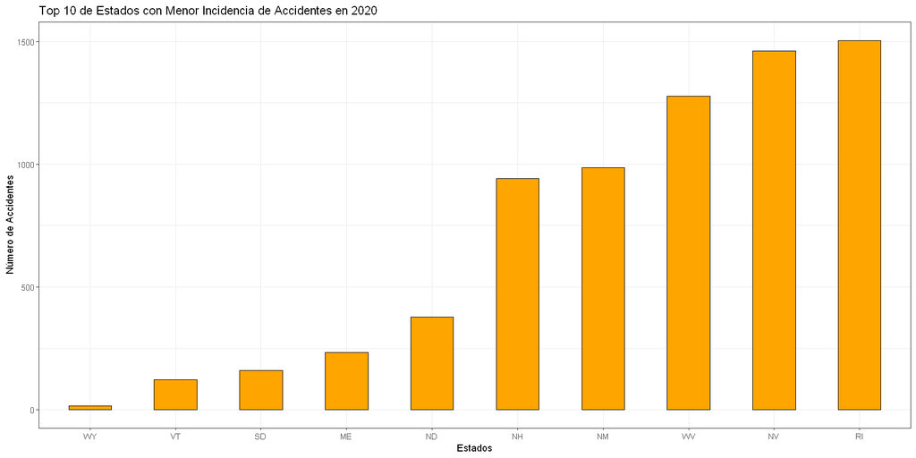

```r
options(repr.plot.width=14, repr.plot.heigth=14)
ggplot(rank_menor, aes(x= reorder(State, Count), y = Count)) +
        geom_bar(stat = "identity", width = .5, fill = "orange", color = "black" ) +
        labs(title="Top 10 de Estados con Menor Incidencia de Accidentes en 2020", y = "Número de Accidentes", x = "Estados") +
        theme_bw()
```

[figure not shown]

> **Wyoming** fue el estado con menor número de accidentes de tránsito registrados durante el 2020

```r
rank_mayor <- accidentes %>%
                group_by(State) %>%
                summarise(Count = n()) %>%
                arrange(Count)

rank_mayor <- tail(rank_mayor, n = 10)
```

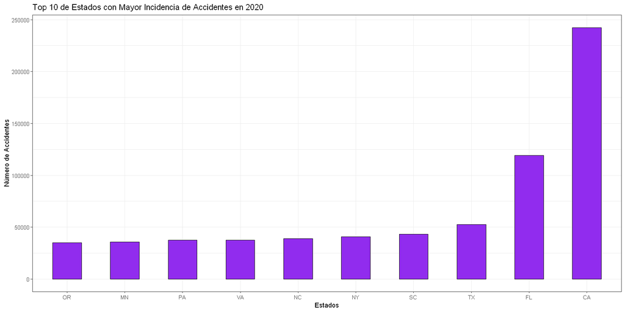

```r
ggplot(rank_mayor, aes(x= reorder(State, Count), y = Count)) +
        geom_bar(stat = "identity", width = .5, fill = "purple2", color = "Black" ) +
        labs(title="Top 10 de Estados con Mayor Incidencia de Accidentes en 2020", y = "Número de Accidentes", x = "Estados") +
        theme_bw()
```

[figure not shown]

> **California** fue el estado con mayor cantidad de accidentes de tránsito durante el 2020.

**¿ En que estados se originan los accidentes con mayor rango de severidad ?**

```r
acc_severidad <- accidentes %>%
                    mutate(Severidad = ifelse(Severity == 1,"Muy Leve",ifelse(Severity==2,"leve",
                                                                         ifelse(Severity == 3,"Medio",
                                                                               "Grave"))))
```

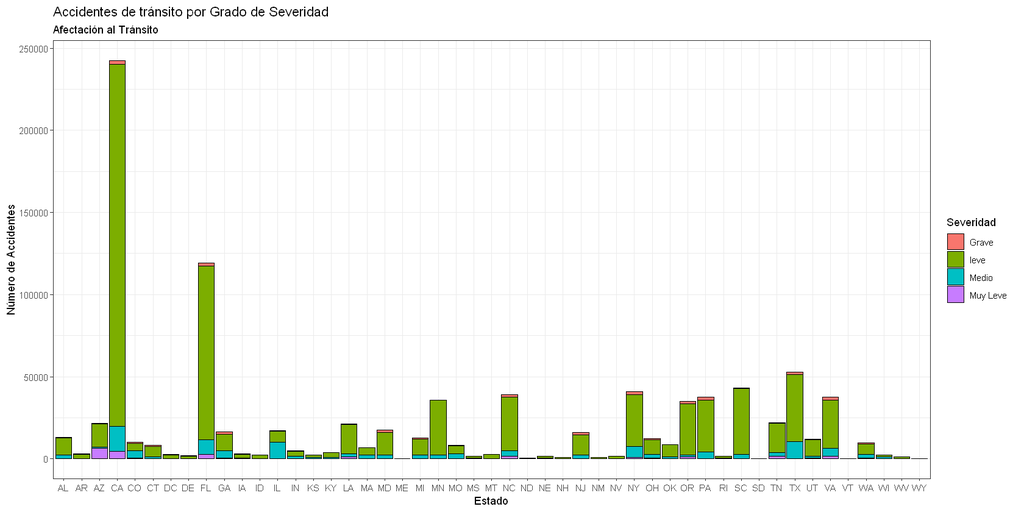

```r
ggplot(acc_severidad,aes(x=State)) +
    geom_bar(aes(fill=Severidad), color = "Black") +
    labs(title="Accidentes de tránsito por Grado de Severidad", subtitle = "Afectación al Tránsito",
         y = "Número de Accidentes", x = "Estado") +
    theme_bw()
```

```r
#Código hecho en R Studio
#Este es el código que genera el mapa de abajo

#accidentes <- read.csv("US_Accidents.csv")
#accidentes <- accidentes[c('ID','Severity','Start_Time','End_Time',
                          # 'Distance.mi.','Description','State','Side',
                           #'Temperature.F.','Wind_Chill.F.','Humidity...',
                           #'Visibility.mi.','Wind_Speed.mph.','Precipitation.in.',
                           #'Weather_Condition','Traffic_Signal','Junction',
                           #'Start_Lng','Start_Lat')]
#diciembre <- accidentes %>%
               # na.omit() %>%
               # mutate(Start_Time = ymd_hms(Start_Time),
                      # Mes = month(Start_Time, label = TRUE),
                      # Dia = mday(Start_Time)) %>%
                #filter(Mes == "dic" & Dia == 31)
#paleta <- colorNumeric(palette = "Set1", domain = diciembre$Severity)

#leaflet(diciembre) %>%
  #addTiles() %>%
  #addCircleMarkers(~Start_Lng, ~Start_Lat,
                  # popup = paste(
                     # "<b>Clima:</b>",
                    # diciembre$Weather_Condition,
                    # "<br><b>Severity:<b>",
                    # diciembre$Severity,
                    # "<br><b>Distance:</b>",
                    # diciembre$Distance.mi.),
                   #stroke = F, color = ~paleta(diciembre$Severity),
                  # radius = ~Distance.mi.* 4,
                  # fillOpacity = 0.4, clusterOptions = markerClusterOptions())
```

**Mapa de Accidentes 31 de Diciembre del 2020**

```r
IRdisplay::display_html('<iframe src="mapa.html" width=700 height=400></iframe>')
```

[interactive chart not shown]

Como se observa en el mapa anterior la cantidad de accidentes que se originan en un solo día en los Estados Unidos es bastante alta y alarmante.

### Hipótesis 2

#### Clima en los Estados Unidos

Los Estados Unidos contiguos cubren un área enorme y, por lo tanto, es lógico que presenten una notable variedad climática. En general, sin embargo, tienen un clima continental, con inviernos fríos (a menudo gélidos) y veranos calurosos (a menudo muy calurosos), con diferentes estaciones dependiendo de la latitud y de la distancia del mar. Sin embargo, hay excepciones: la costa del Pacífico occidental, fresca y húmeda en el norte y mediterránea en el sur; la costa del golfo de México, templada en invierno y bochornosa en verano; Florida, casi tropical; las zonas montañosas, frías todo el año; el área de los desiertos cálidos. Como no hay obstáculos para el descenso del aire frío desde Canadá, casi todo el país puede experimentar repentinas olas frío en invierno, que sin embargo tienen una intensidad y duración diferentes según el área. Los períodos fríos duran unos días en el sur, donde la temperatura desciende unos pocos grados bajo cero en invierno, mientras que son intensos y a veces largos en las zonas del interior, en las mesetas y en el noreste. Incluso las olas de calor del verano pueden ser intensas, especialmente en las zonas del interior. En general, la mitad occidental es más árida que la mitad oriental, con la excepción de la costa del Pacífico centro-norte, que es lluviosa.

**¿ Como influyen las condiciones climáticas en la provocación de accidentes de viales ?**

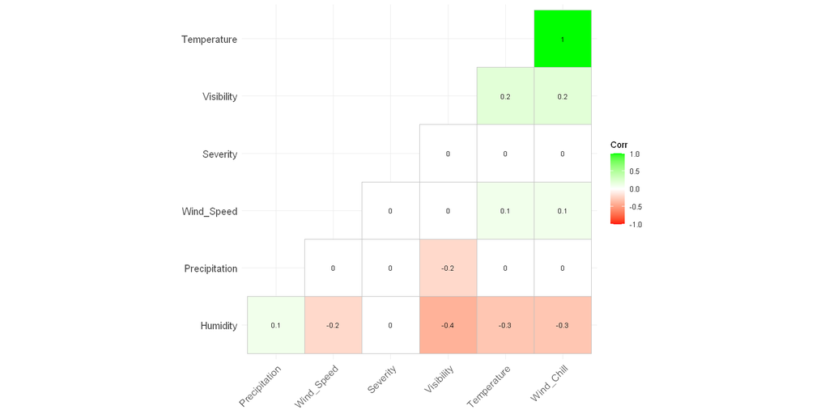

```r
library(ggcorrplot)
acc <- accidentes %>%
        select(Severity,Temperature:Precipitation)
corr <- round(cor(acc),1)
ggcorrplot(corr, hc.order=TRUE, type="lower", lab=TRUE, lab_size=3, method= "square",
          colors=c("red","white","green"))
```

**¿ Cúal es el número de accidentes de tránsito por condiciones del tiempo ?**

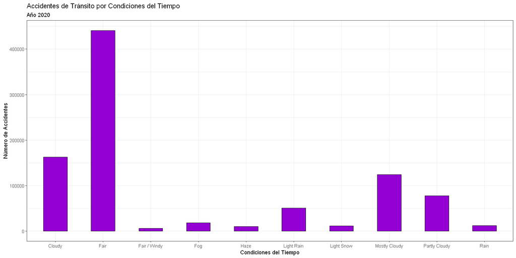

```r
accidentes %>%
        group_by(Weather_Condition) %>%
        summarise(Total = n()) %>%
        arrange(Total) %>%
        tail(n = 10) %>%
        ggplot(aes(x=Weather_Condition, y=Total)) +
        geom_bar(stat="identity", width=.5,fill="darkviolet", color="black") +
        labs(title="Accidentes de Tránsito por Condiciones del Tiempo", subtitle="Año 2020",
             x="Condiciones del Tiempo", y="Número de Accidentes") +
        theme_bw()
```

La condición del tiempo donde se originan mayor número de accidentes es **"Fair"**. Qué es un término algo subjetivo cuando se trata de descripciones meteorológicas generales. En un sentido mas específico esta palabra puede ser usada en un pronóstico u observación del servicio meteorológico, cuando menos de 3/8 del cielo está cubierta por nubes opacas, no hay precipitación, la visibilidad es ilimitada y no hay extremos de temperatura o vientos (lo que generalmente significa que no es anormalmente frío o cálido para la temporada y la hora del día y que los vientos son unos 10 nudos o menos.

[figure not shown]

> Vista satelital de condición atmosférica fair.

**¿ Cuál es el promedio de temperatura, humedad, visibilidad, velocidad del viento y precipitación cuando ocurre un accidente de tránsito ?**

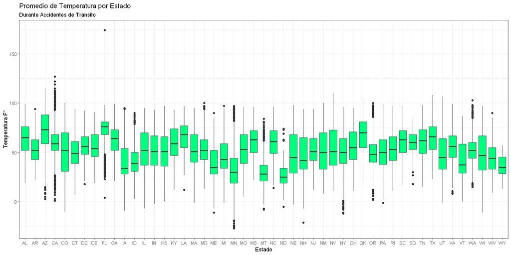

```r
ggplot(accidentes, aes(y=Temperature, x=State)) +
    geom_boxplot(fill="springgreen") +
    labs(title="Promedio de Temperatura por Estado", subtitle="Durante Accidentes de Tránsito",
        x="Estado", y="Temperatura F°") +
    theme_bw()
```

La temperatura promedio durante un accidente de tránsito en cualquiera de los estados ronda entre los **25°** y **85°** grados fahrenheit. Aunque como se nota en el gráfico debido a la extensión de terreno de los Estados Unidos y la variedad de climas que posee, se observa una varianza considerable entre algunos estados.

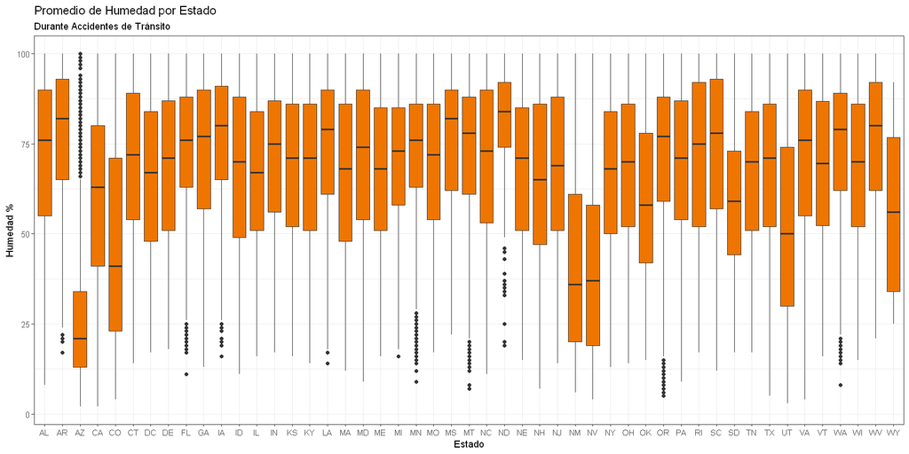

```r
ggplot(accidentes, aes(y=Humidity, x=State)) +
    geom_boxplot(fill="darkorange2") +
    labs(title="Promedio de Humedad por Estado", subtitle="Durante Accidentes de Tránsito",
        x="Estado", y="Humedad %") +
    theme_bw()
```

En caso de la húmedad los porcentajes son muy similares entre estado con algunas excepciones. Por ejemplo **Arizona** ronda alrededor del **15%** y **30%**, mientras que en **Arkansas** entre **65%** y **95%**.

```r
#Se carga la librería gridExtra para hacer grupos de gráficos
library(gridExtra)
```

```r
clima <- accidentes %>%
         group_by(State) %>%
         summarise(Precipitacion = mean(Precipitation), Velocidad_Viento = mean(Wind_Speed),
                   Visibilidad = mean(Visibility))
```

```r
g1 <- ggplot(clima,aes(x=State,y=Precipitacion)) +
          geom_bar(stat="identity", aes(fill=State), color="black") +
          labs(title="Promedio de Precipitación por Estado", subtitle="Durante Accidentes de Tránsito",
               x="Estado", y="Precipitación in") +
          theme_bw() +
          theme(legend.position = "None")
```

```r
g2 <- ggplot(clima,aes(x=State,y=Visibilidad)) +
          geom_bar(stat="identity", aes(fill=State), color="black") +
          labs(title="Promedio de Visibilidad por Estado", subtitle="Durante Accidentes de Tránsito",
               x="Estado", y="Visibilidad mi") +
          theme_bw() +
          theme(legend.position = "None")
```

```r
g3 <- ggplot(clima,aes(x=State,y=Velocidad_Viento)) +
          geom_bar(stat="identity", aes(fill=State), color="black") +
          labs(title="Promedio de Velocidad del Viento por Estado", subtitle="Durante Accidentes de Tránsito",
               x="Estado", y="Velocidad del Viento mph") +
          theme_bw()  +
          theme(legend.position = "None")
```

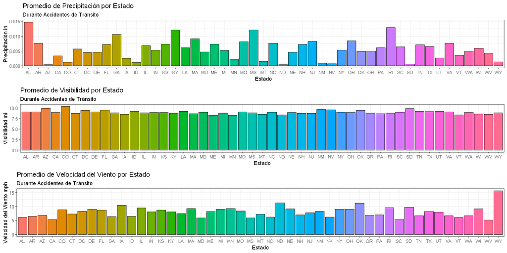

```r
grid.arrange(g1,g2,g3,nrow=3)
```

Condiciones del clima como la temperatura, precipitación, velocidad del viento, húmedad o visibilidad generan circunstancias peligrosas al conducir, por lo que se convierten en un factor importante de riesgo en accidentes de tránsito. En el caso de la precipitación hay una gran variabilidad en la cantidad de pulgadas de lluvia que caen durante un accidente, y esto va muy relacionado con los diferentes tipos de clima que se pueden encontrar en cada estado. A diferencia la visibilidad es muy constante sin importar el estado en el que se originó el accidente, y la velocidad del viento es variable pero en menor rango que la precipitación.